# HW1_Keven_Lin

Keven Lin

8/26/2021

This homework is more or less a tutorial that helps you set up the coding environment used in this course, and familiarizes you with the format of the assignment submission. As a pre-requisite of this homework, first install R, and then the RStudio (the free version of Rstudio Desktop).

Please respond to all questions. If the question asks you to do something on your laptop and you have finished that, just say “Done”.

1. Create a folder named `ds202_hw1`, and **either** create an RMarkDown file `hw1_FirstName_LastName.Rmd` under this folder **or** move the provided template into this folder. Replace `FirstName` and `LastName` with your first and last name. `hw1_FirstName_LastName.Rmd` will include your solutions. The file and folder names are *case-sensitive*, which means `hw1.Rmd` and `HW1.rmd` are different. *It is crucial to follow the exact folder structure and file names* in this course, so that your homework can be reproduced. The correct folder structure is

   ```
   ds202_hw1
   |-- hw1_FirstName_LastName.Rmd
   |-- hw1_FirstName_LastName.html (generated after knitting)
   ```

   Answer: Done? (Note that the start of your answer on the next line must be indented. In other words, don’t remove the leading spaces.)
2. Write your name in the YAML of your homework `Rmd` file.

   Answer: Done
3. Write a paragraph to introduce yourself. Set your name in bold font and your major in italic.

   My name is **Keven Lin** and I’m majoring in *Software Engineering* with minors in Cyber Security and Data Science. This summer I was an application developer intern on MyAccount customer portal team at Securian Financial. After graduation, I want to move out to California and hopefully work for a major tech company (also I hate the cold).
4. Write a paragraph describing a job that you think is related to data science. Include a hyperlink and an image. Make sure your answer is in a nice format to read.

   An example of an occupation that utilized data science is being an Data Engineer at Zillow. Their duty will consist of gathering and analysising data from property sales, county assessments, and regional demand to generate a realistic property valudation for the the seller. A Data Engineer is critical to the business as they develop applications that analyze data trends and create tools for the use in machine learning. Some technologies that a data engineer will utilized is Spark, R, Python, and AWS technologies. https://www.zillow.com/tech/data-science-overview-2017/

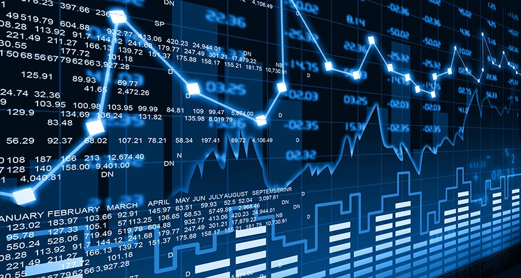

5. What data topic will you be most interested in? (Optional) Provide a source of such dataset if you have.

   Some data topics that I will be most interested in is real estate data. After I get a full time job, I want to get my hands on the regions Real Estate Data and utlized my coding and data science skills to invest and develop a profitable protfolio.
6. To check that your R and Rstudio installation is correct, find the version of R by entering `version` into the R console. Include this command into a R code trunk in your solution `Rmd` file to have it automatically printed in the knitted html file.

   ```r
   version
   ```

   ```
   ##                _
   ## platform       x86_64-w64-mingw32
   ## arch           x86_64
   ## os             mingw32
   ## system         x86_64, mingw32
   ## status
   ## major          4
   ## minor          1.1
   ## year           2021
   ## month          08
   ## day            10
   ## svn rev        80725
   ## language       R
   ## version.string R version 4.1.1 (2021-08-10)
   ## nickname       Kick Things
   ```

7. Install git.
   - If you are on Windows:
     1. Install [Git for Windows](https://gitforwindows.org/). In the coming weeks we will use the Git Bash (but not the Git GUI).
     2. After installation, set up Rstudio to use Git bash as the shell for the Terminal: Open RStudio, click Tools–Global Options–Terminal; under **Shells**, select Git Bash; click OK.
     3. In the main menu of RStudio: click Tools–Terminal–New Terminal. If you have a `$` before your prompt, then you should be good to go.
     4. If you don’t see a `$` before your prompt, try restarting RStudio.
   - If you are on Linux or macOS, Git has probably been installed by default, so you do not need to install anything. Just click the Terminal tab (above the R Console).

   Answer: Done
8. What is the version of your Git? To find out, go to the Terminal tab in RStudio (right to the Console tab), and type in the following command. If it works, this shows that the setup of your terminal and Git is correct.

   ```
   git --version
   ```

   Answer: git version 2.31.1.windows.1
9. Configure your git username and user email by modifying and entering the following commands into the terminal

   ```
   git config --global user.name "your first and last name"
   git config --global user.email "your email"
   ```

   Answer: Done
10. Register a [GitHub](https://www.github.com) account. What is your username?

    Answer: KevenLin2833